# COVID-19 In Toronto Data Analysis

Mingkai Zhang 1004903063

2020-10-02

#Question1

# Part a

```r
#install.packages("opendatatoronto")
#devtools::install_github("sharlagelfand/opendatatoronto")
library(opendatatoronto)
library(tidyverse)
library(visdat)
library(skimr)
library(opendatatoronto)
library(dplyr)
#cesR::get_decon()
```

```r
package <- show_package("64b54586-6180-4485-83eb-81e8fae3b8fe")
resources <- list_package_resources("64b54586-6180-4485-83eb-81e8fae3b8fe")
datastore_resources <- filter(resources, tolower(format) %in% c('csv', 'geojson'))
data <- filter(datastore_resources, row_number()==1) %>% get_resource()
```

- The dataset is about COVID-19 cases in Toronto, and it contains patients’ demographic and geographic data since the first case was reported. The reason why I choose this data is that COVID-19 is one of the biggest concerns of this year. This dataset provides more detailed and full-scale information about COVID-19 than what I get from media.So, after analyze dataset of COVID-19, I could get a comprehensive understand of COVID-19 cases in Toronto.It is interesting because I believe there is some unexpected results by analyze the dataset, and the topic of COVID-19 really attracts me.
- A merit of this dataset is that it update weekly, so I could analyze the latest data. But, this dataset contains too many information to depth analynze one aspect. In my analysis,I will focus on the reported date of every COVID-19 cases because it shows the change in number of confirmed in Toronto by the time.

# Part b

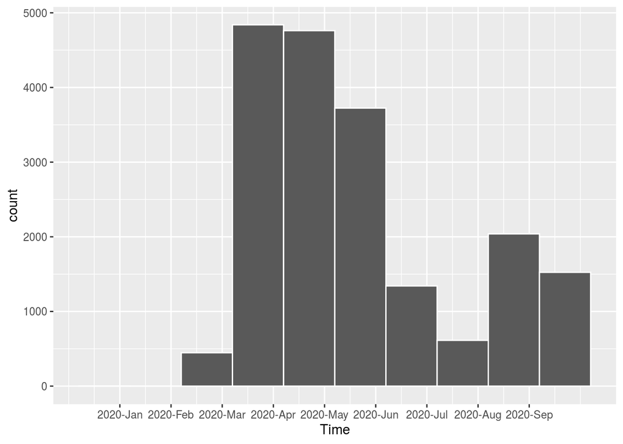

```r
library(ggplot2)
library(scales)
data$`Reported Date` <- as.Date(data$`Reported Date`)
ggplot(data, aes(x=`Reported Date`)) + geom_histogram(binwidth=30, colour="white") +
       scale_x_date(labels = date_format("%Y-%b"),
                    breaks = seq(min(data$`Reported Date`)-5, max(data$`Reported Date`)+5, 30)) +
         xlab("Time")
```

- The histogram above shows the amount of confirmed caese of COVID-19 by the time. In April 2020,the confirmed cases is highest.And, in January and Febuary the confirmed cases close to zero. The graph is not simliar to normal distribution.

# Part c

```r
data%>%
  count(`Age Group`,Classification)%>%
  filter(Classification=="CONFIRMED")%>%
  #group_by(`Age Group`)%>%
  summarise(`Age Group`, num_of_confirmed=n)
```

```
## # A tibble: 10 x 2
##    `Age Group`    num_of_confirmed
##    <chr>                     <int>
##  1 19 and younger             1093
##  2 20 to 29 Years             3187
##  3 30 to 39 Years             2745
##  4 40 to 49 Years             2433
##  5 50 to 59 Years             2719
##  6 60 to 69 Years             1819
##  7 70 to 79 Years             1147
##  8 80 to 89 Years             1546
##  9 90 and older               1124
## 10 NaN                           3
```

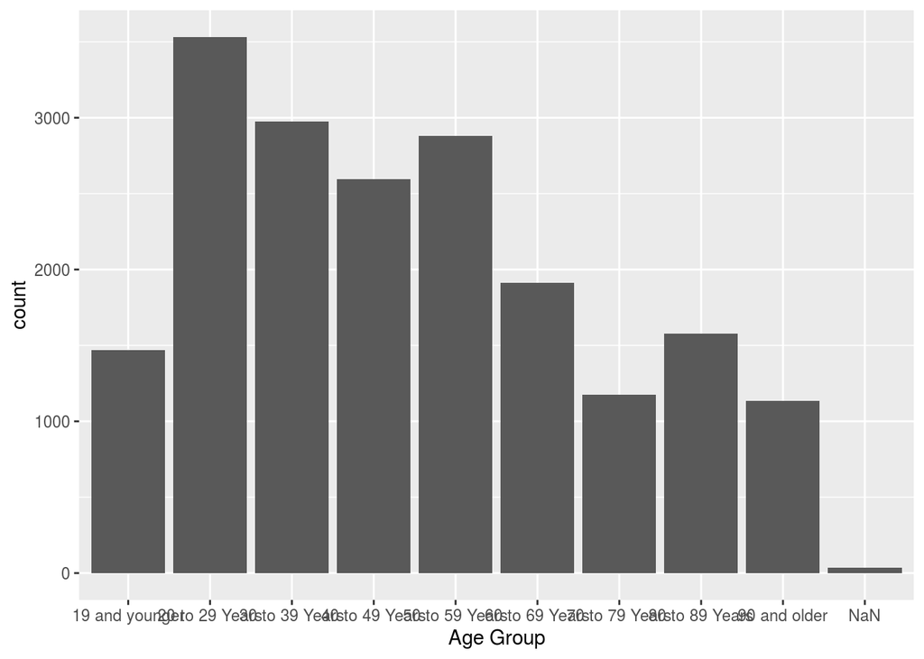

```r
data%>%
  ggplot(aes(x=as.factor(data$`Age Group`)))+geom_bar(stat = 'count',bins=10)+labs(x="Age Group")
```

- The table and the bar plot shows the amount of confirmed cases in each age groups. The 20 to 29 age group get highest amount of cases.And,there is 3 people ungrouped becasue the missing age data.

# Part d

#Reference

1. Wickham et al., (2019). Welcome to the tidyverse. Journal of Open Source Software, 4(43), 1686, https://doi.org/10.21105/joss.01686